# Ajuste entre distribuições e dados

Delineamento e Estatística

Nicholas A. C. Marino

github.com/nacmarino/metodosR

## O que é um modelo de regressão?

- Um modelo de regressão visa determinar a relação entre uma ou mais variáveis resposta (*y<sub>1</sub>*, *y<sub>2</sub>*, *y<sub>3</sub>*,…, *y<sub>i</sub>*) e preditoras (*x<sub>1</sub>*, *x<sub>2</sub>*, *x<sub>3</sub>*,…, *x<sub>i</sub>*).
- Um modelo de regressão pode ser visualizado na forma:

*$\bar{y}$* = $\beta$<sub>0</sub> + $\beta$<sub>1</sub> *x*<sub>1</sub> + $\beta$<sub>2</sub> *x*<sub>2</sub> + … + $\beta$<sub>i</sub> *x*<sub>i</sub> + $\epsilon$

### O que são os coeficientes nestes modelos?

- Neste modelo, cada coeficiente $\beta$<sub>i</sub> (i > 0) representa o efeito da variável preditora *x<sub>i</sub>* sobre a variável resposta *$\bar{y}$* - isto é, o quanto cada unidade de aumento/redução nos valores de *x<sub>i</sub>* alteram os valores de *$\bar{y}$*: estes são os **slopes** da regressão.
- O coeficiente $\beta$<sub>0</sub> representa o **intercepto** do modelo - isto é, o valor que a variável resposta *$\bar{y}$* assume quando os valores de cada variável preditora *x<sub>i</sub>* é igual a zero.
- O coeficiente $\epsilon$ representa o erro na estimativa do valor da variável resposta *$\bar{y}$* de acordo com o modelo.
- No exemplo abaixo:

*$\bar{Preço}$* = $\beta$<sub>0</sub> + $\beta$<sub>Peso</sub> *x*<sub>Peso</sub> + $\epsilon$

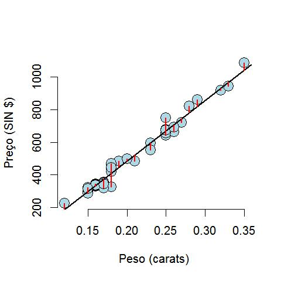

### Mas o que representa cada um dos valores de $\beta$ em um modelo?

- Primeiro, vamos criar um vetor abaixo para analisarmos e entendermos melhor essa pergunta.

```r
set.seed(33)
dados <- round(rnorm(n = 50, mean = 100, sd = 30), digits = 0)
dados # vetor de números aleatórios gerado de acordo com uma distribuição normal
```

```
##  [1]  96  99 130  95  35 115  77 123 123  67 105  99 156 107 121 100  96
## [18] 110 104  82  87 109 122 114 106 107 118 160  45  74 147 105  92 124
## [35]  93 142  85 104 100  78  78  94 140 111 125 123 102  80 155  94
```

- Agora, vamos criar um modelo de regressão linear simples, contendo apenas o seu intercepto utilizando a função `lm`.

```r
summary(lm(dados ~ 1))
```

```
##
## Call:
## lm(formula = dados ~ 1)
##
## Residuals:
##    Min     1Q Median     3Q    Max
## -70.08 -11.83  -0.58  16.67  54.92
##
## Coefficients:
##             Estimate Std. Error t value Pr(>|t|)
## (Intercept)  105.080      3.603   29.17   <2e-16 ***
## ---
## Signif. codes:  0 '***' 0.001 '**' 0.01 '*' 0.05 '.' 0.1 ' ' 1
##
## Residual standard error: 25.47 on 49 degrees of freedom
```

### No que se baseiam os valores de `Estimate`, `Std. Error` e `Residual standard error`?

- Lembre-se que os coeficientes de uma regressão são determinados a partir dos valores que minimizam a variação residual do modelo - a parte da variância nos dados que não é explicada pelo modelo.
- No gráfico que exploramos anteriormente, esta variação residual é representada pelas linhas vermelhas que conectam a reta da regressão à cada uma das observações.

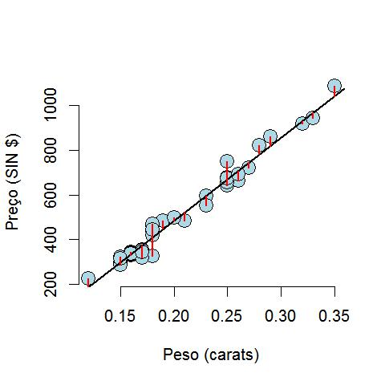

- Para dados que seguem a distribuição normal, quais são os valores esperados que melhor representam a medida de centralidade dos dados e variação ao redor deste centro?

```r
mean(dados)
```

```
## [1] 105.08
```

```r
sd(dados)
```

```
## [1] 25.47415
```

- A **média** representa o valor esperado mais provável para uma observação que venha de uma população *X*: `Estimate`;
- O **desvio padrão** representa o valor esperado mais provável da diferença total existente entre as observações em uma população *X* e o valor central que descreve esta população: `Residual standard error`.
- A diferença média do quanto cada observação se afasta do valor esperado para a média de uma população é **erro padrão**: `Std. Error`.
- Com os valores do `Estimate` e do `Std. Error` podemos calcular o intervalo de confiança para a estimativa de cada parâmetro no modelo.
  - É um intervalo de valores que possui uma grande chance de conter o valor real de um parâmetro que descreve uma população.
  - Intervalo de confiança para a média:

$\beta$<sub>i</sub> $\pm$ 1.96 * SE

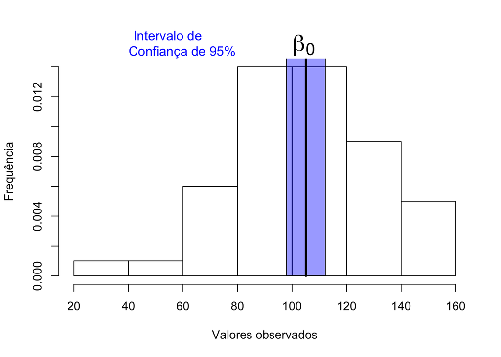

- Podemos chegar no mesmo resultado obtido com a função `lm` quando usamos a função `glm` (falaremos mais sobre as GLMs mais a frente):

```r
summary(glm(dados ~ 1, family = gaussian))
```

```
##
## Call:
## glm(formula = dados ~ 1, family = gaussian)
##
## Deviance Residuals:
##    Min      1Q  Median      3Q     Max
## -70.08  -11.83   -0.58   16.67   54.92
##
## Coefficients:
##             Estimate Std. Error t value Pr(>|t|)
## (Intercept)  105.080      3.603   29.17   <2e-16 ***
## ---
## Signif. codes:  0 '***' 0.001 '**' 0.01 '*' 0.05 '.' 0.1 ' ' 1
##
## (Dispersion parameter for gaussian family taken to be 648.9322)
##
##     Null deviance: 31798  on 49  degrees of freedom
## Residual deviance: 31798  on 49  degrees of freedom
## AIC: 468.65
##
## Number of Fisher Scoring iterations: 2
```

## Meus dados seguem a família de distribuição de probabilidade normal?

- Podemos usar métodos gráficos ou testes estatísticos para descobrir se os dados se ajustam à distribuição normal.
- Métodos gráficos *vs* métodos estatísticos:
  - Os testes estatísticos são influenciados pelo tamanho da amostra;
  - Os testes estatísticos são influenciados por outliers;
  - Estes testes estatísticos são sensíveis à desvios na normalidade.
  - **Minha recomendação**: use a visualização gráfica.

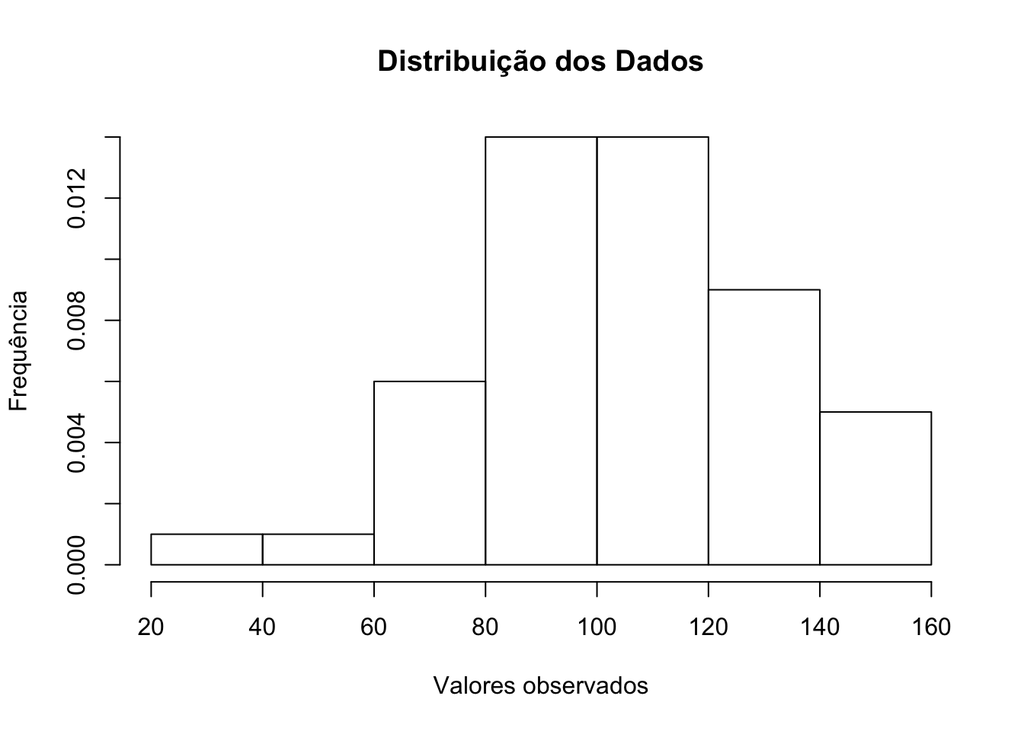

```r
# histograma de distribuição dos dados gerados
hist(x = dados, main = "Distribuição dos Dados", xlab = "Valores observados", ylab = "Frequência", freq = FALSE)
```

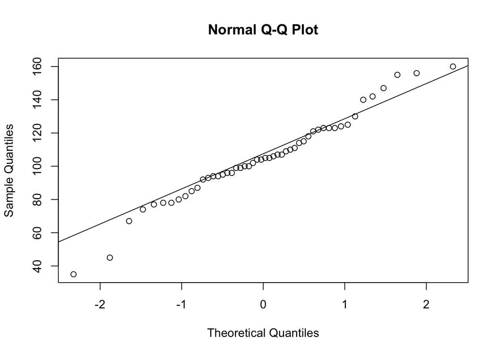

```r
# QQ-Plot: plot da distribuição dos valores observados de acordo com uma expectativa teórica baseado nos quantis da distribuição
qqnorm(y = dados);qqline(y = dados)
```

```r
# Teste de Shapiro-Wilk: testa a hipótese nula de que a população de dados segue a distribuição normal
shapiro.test(x = dados)
```

```
##
##  Shapiro-Wilk normality test
##
## data:  dados
## W = 0.97515, p-value = 0.3696
```

## E quando não sabemos o tipo de família de distribuição de probabilidade dos nossos dados?

- Na maior parte das vezes não temos a menor noção de que tipo de família de distribuição de probabilidade nossos dados seguem.
- Lembre-se que cada família de distribuição de probabilidade é descrita por um conjunto diferente de parâmetros.
- Estes parâmetros também descrevem os valores esperados mais prováveis para medidas de centralidade e variação ao redor do centro para cada uma destas distribuições estatísticas.
- O pacote `fitdistrplus` oferece alguns métodos para determinamos a distribuição mais adequada para um conjunto de dados cuja natureza da distribuição de probabilidade não é conhecida.
- A função `fitdist` ajusta uma distribuição a um conjunto de dados e estima os parâmetros daquela distribuição.

```r
library(fitdistrplus)
ajuste1 <- fitdist(data = dados, distr = "norm")
coef(object = ajuste1) # compare com os valores esperados para a média, o desvio padrão e os resultados da função lm acima
```

```
##      mean        sd
## 105.08000  25.21812
```

> A função `fitdist` usa um estimador por verossimilhança máxima para determinar o valor mais provável para cada um dos parâmetros da distribuição de probabilidade - valor do parâmetro que minimiza a soma dos quadrados de um conjunto de dados.
- Podemos usar a função `fitdist` para ajustar outras famílias de distribuição de probabilidade.

```r
coef(object = fitdist(data = dados, distr = "pois"))
```

```
## lambda
## 105.08
```

```r
coef(object = fitdist(data = dados, distr = "gamma"))
```

```
##      shape       rate
## 14.9285055  0.1420702
```

```r
coef(object = fitdist(data = dados, distr = "weibull"))
```

```
##      shape      scale
##   4.610286 114.733145
```

```r
coef(object = fitdist(data = dados, distr = "lnorm"))
```

```
##   meanlog     sdlog
## 4.6208445 0.2759799
```

- Este pacote possui outras três funções muito úteis para entender e determinar o tipo de família de distribuição de probabilidade que melhor se ajusta a um conjunto de dados:
  - `gofstat`: computa um teste para determinar o ajuste dos dados a uma ou mais famílias de distribuição de probabilidade;
  - `cdfcomp`: método gráfico que compara o ajuste dos dados a uma ou mais famílias de distribuição de probabilidade baseado na função de distribuição cumulativa da probabilidade (probabilidade acumulada de obter um valor *x* maior ou igual a um dado valor *X* determinado).
  - `descdist`: método gráfico que descreve os parâmetros gerais da distribuição de um conjunto de dados, bem como uma estimativa da kurtose e obliquidade dos dados (*skewness*) - conhecido como Gráfico de Cullen e Frey.

[figure not shown]

- A função `gofstat` fornece uma medida quantitativa do quanto o uso de uma ou outra família de distribuição de probabilidade são capazes de descrever um conjunto de dados.

```r
ajuste1 <- fitdist(data = dados, distr = "norm")
ajuste2 <- fitdist(data = dados, distr = "pois")
gofstat(f = list(ajuste1, ajuste2), fitnames = c("Normal", "Poisson"))
```

```
## Goodness-of-fit statistics
##                                  Normal    Poisson
## Kolmogorov-Smirnov statistic 0.08199382  0.2227724
## Cramer-von Mises statistic   0.05954226  0.6534471
## Anderson-Darling statistic   0.41092913 15.9666444
##
## Goodness-of-fit criteria
##                                  Normal  Poisson
## Aikake's Information Criterion 468.6501 644.3701
## Bayesian Information Criterion 472.4742 646.2821
```

- A função `cdfcomp` é um método gráfico para determinarmos o quanto os valores de um conjunto de dados são bem ajustados por uma ou outra família de distribuição de probabilidade.

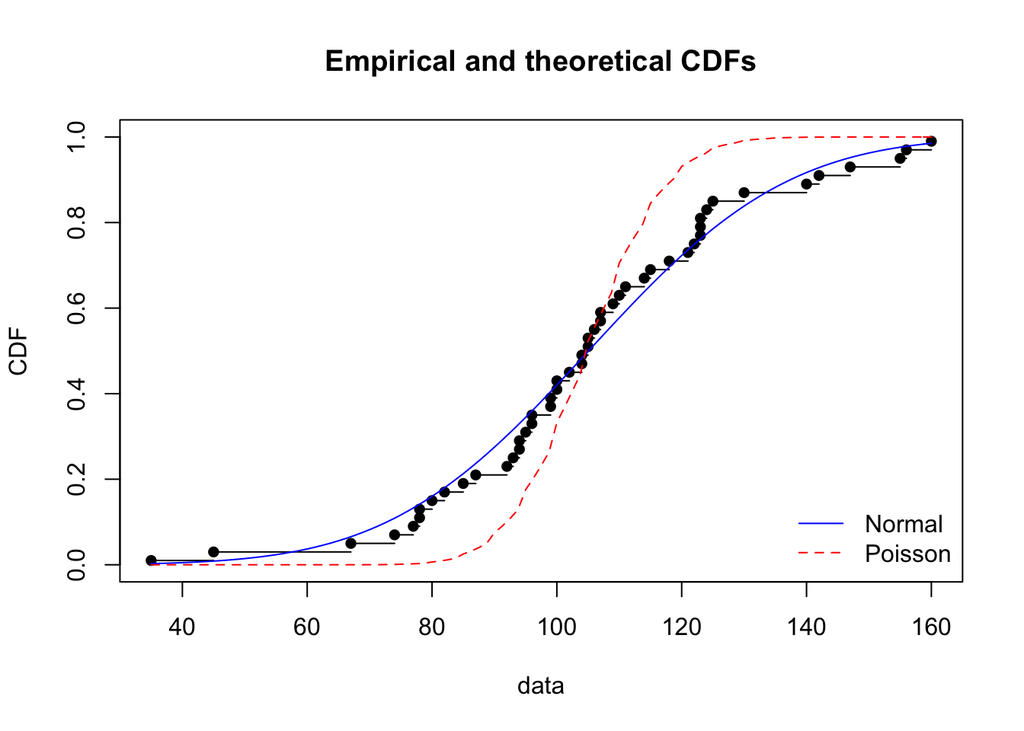

```r
cdfcomp(ft = list(ajuste1, ajuste2), fitcol = c("blue", "red"), legendtext = c("Normal", "Poisson"))
```

- Uma outra função útil é a `descdist`, que oferece um método gráfico capaz de ajudar a determinar de qual tipo de distribuição um conjunto de dados melhor se aproxima.

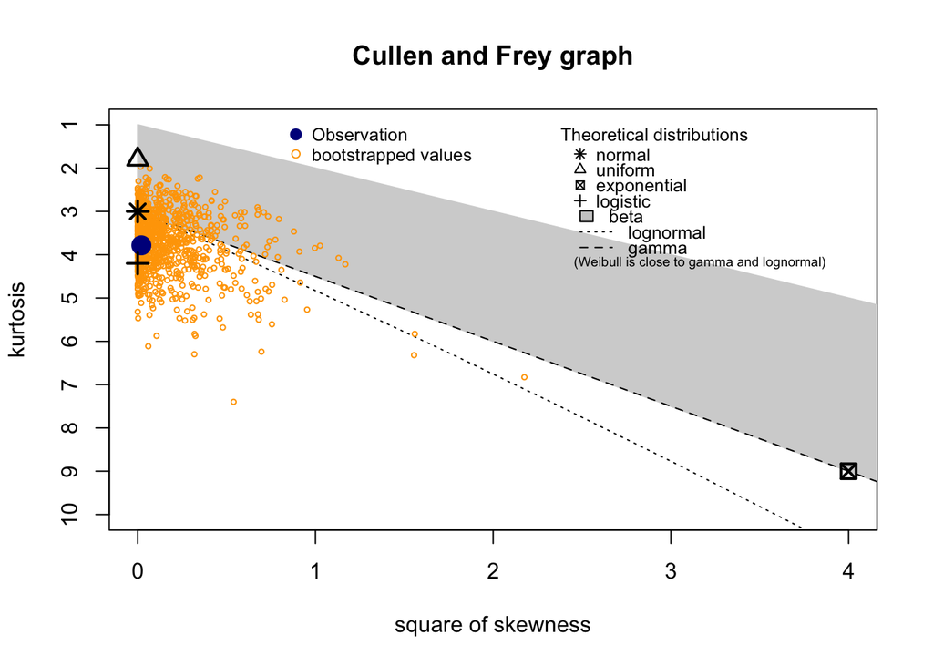

```
## summary statistics
## ------
## min:  35   max:  160
## median:  104.5
## mean:  105.08
## estimated sd:  25.47415
## estimated skewness:  -0.1427609
## estimated kurtosis:  3.782758
```

```r
descdist(data = dados, boot = 1000)
```

## Existe algum preço ao escolhermos usar uma ou outra família de distribuição de probabilidade nos modelos?

- Depende do seu objetivo: predição ou compreensão?
- Usar a família de distribuição de probabilidade errada pode aumentar a chance de um Erro do Tipo I: falso positivo.
  - *Overdispersion*: a estimativa do erro de um parâmetro é **subestimada** - a distribuição estatística prevê que a dispersão do conjunto de dados é menor do que real.
  - Outra forma de ver isso: os dados estão mais dispersos do que o esperado pela família de distribuição de probabilidade.
  - Ocorre principalmente quando tentamos utilizar a distribuição `poisson` ou `binomial` - ambas assumem que a variância é igual à média.

```r
set.seed(33)
dados <- round(rnorm(n = 100, mean = 1500, sd = 600))
dt1 <- fitdist(dados, "norm")
dt2 <- fitdist(dados, "pois")
(dt1 <- bootdist(dt1)$CI[1,])
```

```
##   Median     2.5%    97.5%
## 1531.638 1410.960 1651.112
```

```r
(dt2 <- bootdist(dt2)$CI)
```

```
##  Median    2.5%   97.5%
## 1535.53 1528.99 1543.29
```

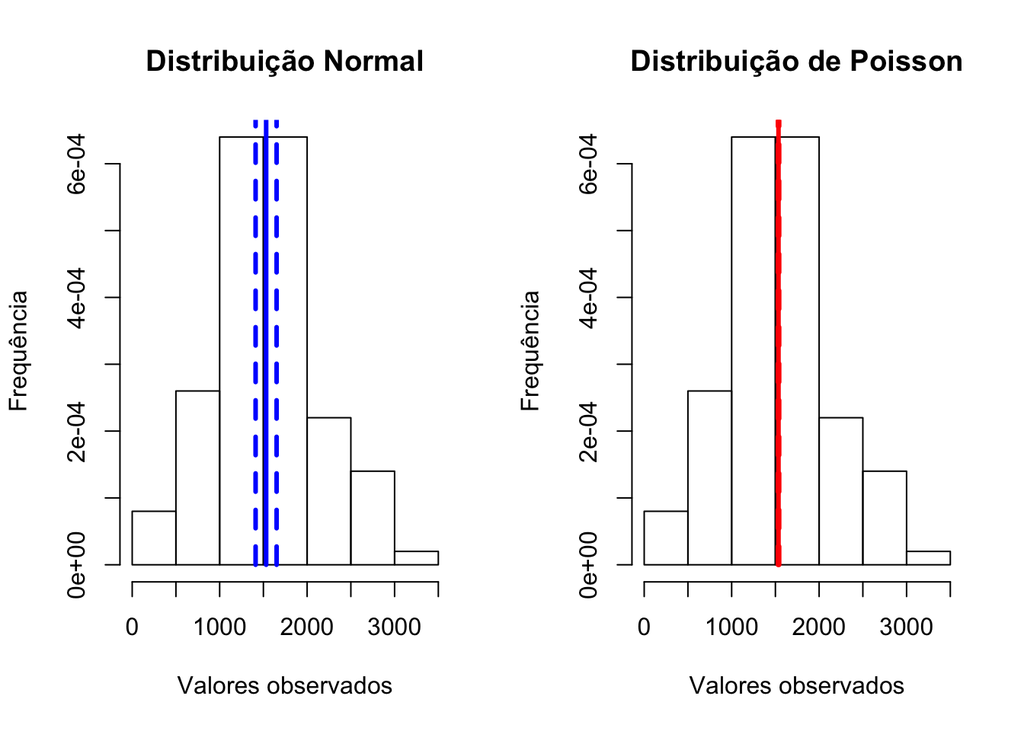

## Pensamento final: o que fazer quando os dados não são normais?

- Transformações para normalizar os dados podem ser úteis e, até mesmo, um método preferível quando o seu objetivo é a predição.
- As GLMs podem ser usadas para criar modelos utilizando outras famílias de distribuição de probabilidade.
- O forte desta classe de modelos é que ele pode ser usado quando os **resíduos** de uma modelo linear não são normais.
  - General Linear Models: distribuição dos resíduos do modelo segue a distribuição normal (`lm`, `glm::gaussian`).
  - General__ized__ Linear Models: distribuição dos resíduos do modelo não segue a distribuição normal (`glm`).